# R Notebook

```r
df <- read_csv("final_df.csv")
```

#Missing Values One row stands for 50 Songs in a interval-based rating from 1 to 7 where 1 represent the answer “I don’t know this song”

Set value 1 to NA and check all NAs:

```r
df[-1] <- na_if(df[-1], 1)

apply(df[-1], 2, function(x) sum(is.na(x)))
```

```
##  SongNr_1  SongNr_2  SongNr_3  SongNr_4  SongNr_5  SongNr_6  SongNr_7
##         1         2         1         5         4         0         4
##  SongNr_8  SongNr_9 SongNr_10 SongNr_11 SongNr_12 SongNr_13 SongNr_14
##         4        10         3         7        10         8         6
## SongNr_15 SongNr_16 SongNr_17 SongNr_18 SongNr_19 SongNr_20 SongNr_21
##         8        17        15        23        33        29        23
## SongNr_22 SongNr_23 SongNr_24 SongNr_25 SongNr_26 SongNr_27 SongNr_28
##        19        15        21        24        20        37        58
## SongNr_29 SongNr_30 SongNr_31 SongNr_32 SongNr_33 SongNr_34 SongNr_35
##         0         2         1         1         3         2         0
## SongNr_36 SongNr_37 SongNr_38 SongNr_39 SongNr_40 SongNr_41 SongNr_42
##         0         1         1         5         5         2         6
## SongNr_43 SongNr_44 SongNr_45 SongNr_46 SongNr_47 SongNr_48 SongNr_49
##         9         5         9         9         7         8         5
## SongNr_50
##         6
```

```r
mean(apply(df, 2, function(x) sum(is.na(x))))
```

```
## [1] 9.686275
```

```r
apply(df, 1, function(x) sum(is.na(x)))
```

```
##   [1]  0  1  0  2 27  1  0  0  3  0  1  2  0 10  0  0  9 14  1  1  0  0 12
##  [24]  2  8 12  0  8 21  3  1 12  8  1  0  5  2  3  1  4  0  1 22  2  1  2
##  [47]  2 15  1  0 15  5  1 12 14  6  6  2  5  6  1  3  8  7 10  7  3  3  0
##  [70]  0  5 11  3 15  2  5  6  2  0  1  4  2  1  0  8  0  1  1  0  3  1  4
##  [93]  7  2  0  4  1 15  3  8  4  1  0  2  1  7  7  1  2  0  6  2  0  1  1
## [116]  1  0  1  1  6
```

```r
mean(apply(df, 1, function(x) sum(is.na(x))))
```

```
## [1] 4.116667
```

Histgram of the matrix:

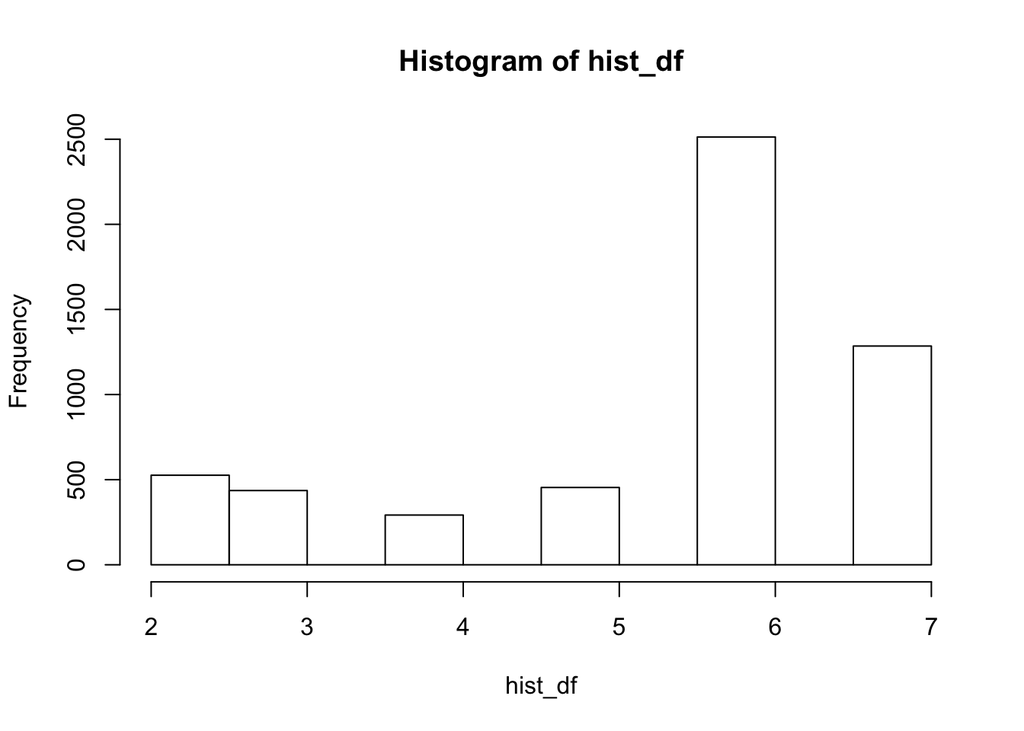

```r
hist_df=data.matrix(df[-1])
hist(hist_df)
```

First we have to preprocess a dataframe without any missing values out of our given data to match the requirments of a classification problem. This dataframe will have to parts the Training Set and the Test Set.

##Trainig Set: This set will be represent by the peer group. All the independent varibales (Songs rated by the ther peer group as well as the new user) and the dependet varaibles (Songs that are only rated by the peer group). The dependet varaibles are the target varables of our classification problem.

First we will we need to identify the most well known Songs:

```r
well_know_songs <- as.data.frame(apply(df[-1], 2, function(x) sum(is.na(x))))
well_know_songs <- setDT(well_know_songs, keep.rownames = TRUE)
well_know_songs <-  well_know_songs %>%
  rename("Number_of_NA" =  "apply(df[-1], 2, function(x) sum(is.na(x)))")  %>%
  arrange(Number_of_NA)
well_know_songs <- head(well_know_songs, n = 20)
```

```r
Names <- c("user", t(well_know_songs[,-2]))
df_classification_training <- subset(df, select=c(Names))
df_classification_training <- na.omit(df_classification_training)
apply(df_classification_training, 2, function(x) sum(is.na(x)))
```

```
##      user  SongNr_6 SongNr_29 SongNr_35 SongNr_36  SongNr_1  SongNr_3
##         0         0         0         0         0         0         0
## SongNr_31 SongNr_32 SongNr_37 SongNr_38  SongNr_2 SongNr_30 SongNr_34
##         0         0         0         0         0         0         0
## SongNr_41 SongNr_10 SongNr_33  SongNr_5  SongNr_7  SongNr_8  SongNr_4
##         0         0         0         0         0         0         0
```

write_csv(df_classification_training, path = “df_classification_training.csv”)